# Rozwiązanie kolokwium poprawkowego — grupa B

Author

Dariusz Majerek

Published

June 10, 2026

## 1. Przegląd danych

Wczytujemy dane `Sacramento` z pakietu `modeldata`.

```r
data("Sacramento")
```

**Struktura** — wymiary i typy zmiennych:

```r
cat("Liczba wierszy:", nrow(Sacramento), "\n")
```

```
Liczba wierszy: 932
```

```r
cat("Liczba kolumn:", ncol(Sacramento), "\n\n")
```

```
Liczba kolumn: 9
```

```r
str(Sacramento, give.attr = FALSE)
```

```
tibble [932 × 9] (S3: tbl_df/tbl/data.frame)
 $ city     : Factor w/ 37 levels "ANTELOPE","AUBURN",..: 34 34 34 34 34 34 34 34 29 31 ...
 $ zip      : Factor w/ 68 levels "z95603","z95608",..: 64 52 44 44 53 65 66 49 24 25 ...
 $ beds     : int [1:932] 2 3 2 2 2 3 3 3 2 3 ...
 $ baths    : num [1:932] 1 1 1 1 1 1 2 1 2 2 ...
 $ sqft     : int [1:932] 836 1167 796 852 797 1122 1104 1177 941 1146 ...
 $ type     : Factor w/ 3 levels "Condo","Multi_Family",..: 3 3 3 3 3 1 3 3 1 3 ...
 $ price    : int [1:932] 59222 68212 68880 69307 81900 89921 90895 91002 94905 98937 ...
 $ latitude : num [1:932] 38.6 38.5 38.6 38.6 38.5 ...
 $ longitude: num [1:932] -121 -121 -121 -121 -121 ...
```

Zbiór zawiera **932 obserwacje** i **9 zmiennych**. Występują zarówno zmienne numeryczne (`beds`, `baths`, `sqft`, `price`, `latitude`, `longitude`), jak i nominalne: `city` — 37 poziomów, `zip` — 68 poziomów, `type` — 3 poziomy. Duża liczba poziomów `zip` będzie wymagać specjalnego traktowania w preprocessingu.

### Braki danych i zmienne o zerowej wariancji

```r
cat("Liczba braków w każdej kolumnie:\n")
```

```
Liczba braków w każdej kolumnie:
```

```r
colSums(is.na(Sacramento))
```

```
     city       zip      beds     baths      sqft      type     price  latitude
        0         0         0         0         0         0         0         0
longitude
        0
```

```r
cat("\nLiczba unikalnych wartości w każdej kolumnie:\n")
```

```
Liczba unikalnych wartości w każdej kolumnie:
```

```r
sapply(Sacramento, function(x) length(unique(x)))
```

```
     city       zip      beds     baths      sqft      type     price  latitude
       37        68         7         9       687         3       602       920
longitude
      920
```

**Komentarz:** Brak braków danych. Wszystkie zmienne mają więcej niż jedną unikalną wartość. `zip` z 68 poziomami to potencjalny problem — zostanie usunięty w recepcie A (MARS) lub zgrupowany w recepcie B i C.

### Rozkład zmiennej wynikowej `price`

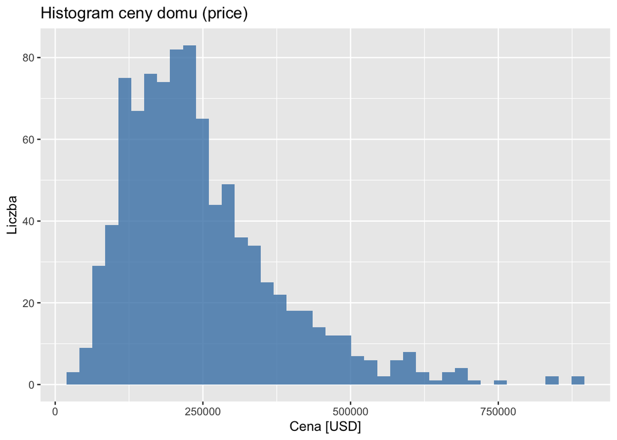

```r
ggplot(Sacramento, aes(x = price)) +
  geom_histogram(bins = 40, fill = "steelblue", alpha = 0.8) +
  labs(title = "Histogram ceny domu (price)", x = "Cena [USD]",
       y = "Liczba")
```

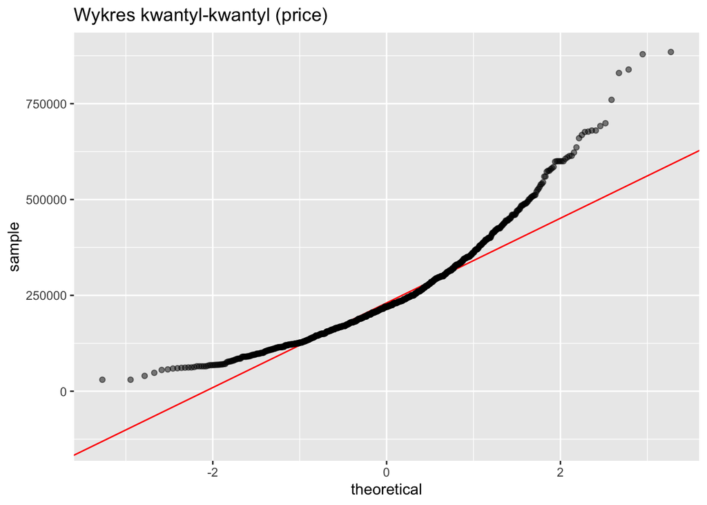

```r
ggplot(Sacramento, aes(sample = price)) +
  geom_qq_line(color = "red") +
  geom_qq(alpha = 0.5) +
  labs(title = "Wykres kwantyl-kwantyl (price)")
```

```r
cat("Skośność price:", skewness(Sacramento$price), "\n")
```

```
Skośność price: 1.3549
```

```r
cat("Kurtoza price:", kurtosis(Sacramento$price), "\n")
```

```
Kurtoza price: 5.537746
```

## 2. Analiza opisowa danych

### Podstawowe statystyki opisowe

```r
Sacramento %>%
  select(price, beds, baths, sqft, latitude, longitude) %>%
  skimr::skim()
```

Data summary

| Name | Piped data |
| --- | --- |
| Number of rows | 932 |
| Number of columns | 6 |
| _______________________ |  |
| Column type frequency: |  |
| numeric | 6 |
| ________________________ |  |
| Group variables | None |

**Variable type: numeric**

| skim_variable | n_missing | complete_rate | mean | sd | p0 | p25 | p50 | p75 | p100 | hist |
| --- | --- | --- | --- | --- | --- | --- | --- | --- | --- | --- |
| price | 0 | 1 | 246661.58 | 131126.86 | 30000.00 | 156000.00 | 220000.00 | 305000.00 | 884790.00 | ▇▇▂▁▁ |
| beds | 0 | 1 | 3.28 | 0.89 | 1.00 | 3.00 | 3.00 | 4.00 | 8.00 | ▃▇▆▁▁ |
| baths | 0 | 1 | 2.05 | 0.72 | 1.00 | 2.00 | 2.00 | 2.00 | 5.00 | ▂▇▂▁▁ |
| sqft | 0 | 1 | 1680.32 | 726.27 | 484.00 | 1166.75 | 1470.00 | 1953.50 | 4878.00 | ▇▇▂▁▁ |
| latitude | 0 | 1 | 38.59 | 0.13 | 38.24 | 38.48 | 38.62 | 38.69 | 39.02 | ▁▆▇▂▁ |
| longitude | 0 | 1 | -121.36 | 0.14 | -121.55 | -121.45 | -121.38 | -121.31 | -120.60 | ▇▅▁▁▁ |

### Wizualizacje zależności między predyktorami a `price`

**Wykres 1: Macierz korelacji** zmiennych numerycznych.

```r
Sacramento %>%
  select(price, beds, baths, sqft, latitude, longitude) %>%
  cor() %>%
  round(2)
```

```
          price  beds baths sqft latitude longitude
price      1.00  0.46  0.58 0.77     0.15      0.36
beds       0.46  1.00  0.66 0.72    -0.05      0.08
baths      0.58  0.66  1.00 0.76     0.05      0.18
sqft       0.77  0.72  0.76 1.00     0.04      0.24
latitude   0.15 -0.05  0.05 0.04     1.00      0.38
longitude  0.36  0.08  0.18 0.24     0.38      1.00
```

**Wykres 2: Powierzchnia vs cena** z kolorem wg typu nieruchomości.

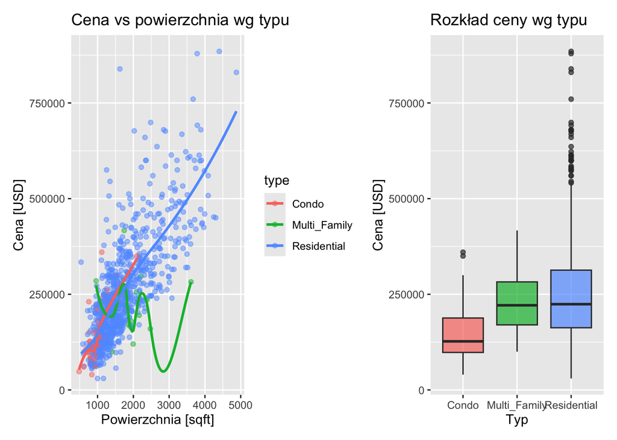

```r
p1 <- ggplot(Sacramento, aes(x = sqft, y = price, color = type)) +
  geom_point(alpha = 0.5) +
  geom_smooth(method = "loess", se = FALSE) +
  labs(title = "Cena vs powierzchnia wg typu",
       x = "Powierzchnia [sqft]", y = "Cena [USD]")

p2 <- ggplot(Sacramento, aes(x = type, y = price, fill = type)) +
  geom_boxplot(alpha = 0.7) +
  labs(title = "Rozkład ceny wg typu", x = "Typ", y = "Cena [USD]") +
  theme(legend.position = "none")

p1 + p2
```

**Wykres 3: Sypialnie i łazienki vs cena.**

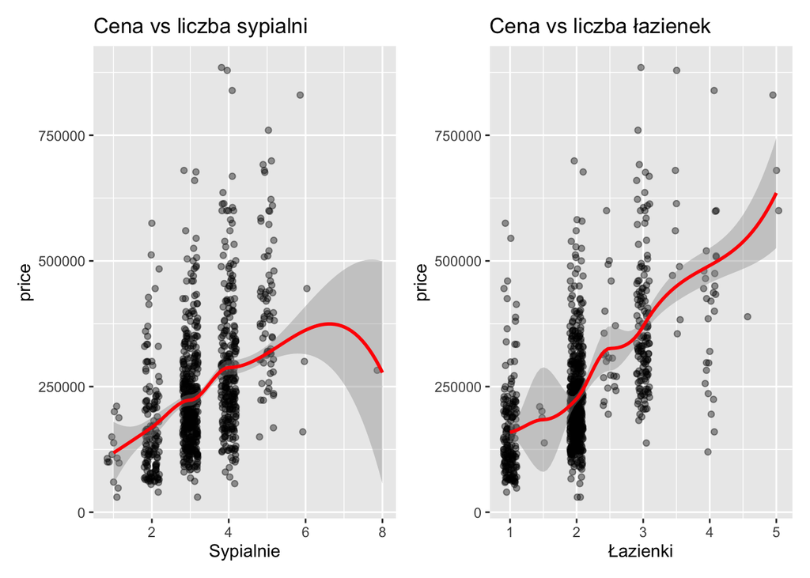

```r
p3 <- ggplot(Sacramento, aes(x = beds, y = price)) +
  geom_jitter(alpha = 0.4, width = 0.2) +
  geom_smooth(method = "loess", se = TRUE, color = "red") +
  labs(title = "Cena vs liczba sypialni", x = "Sypialnie")

p4 <- ggplot(Sacramento, aes(x = baths, y = price)) +
  geom_jitter(alpha = 0.4, width = 0.1) +
  geom_smooth(method = "loess", se = TRUE, color = "red") +
  labs(title = "Cena vs liczba łazienek", x = "Łazienki")

p3 + p4
```

## 3. Przygotowanie preprocessingu — trzy reguły

Każda reguła zawiera usunięcie predyktorów o zerowej wariancji (`step_nzv()`).

Przed definicją receptur tworzymy wersję danych z logarytmem ceny — jest to konieczne, aby silnik `earth` (MARS) akceptował typ zmiennej wynikowej zgodny z typem w danych treningowych.

```r
sac_data <- Sacramento %>%
  mutate(price = log(price))
```

### Reguła A — MARS (silnik earth)

```r
recipe_A <- recipe(price ~ ., data = sac_data) %>%
  step_rm(zip) %>%
  step_nzv(all_predictors()) %>%
  step_other(city, threshold = 0.05) %>%
  step_mutate(city = as.factor(city))
```

**Uzasadnienie:** MARS samodzielnie wykrywa nieliniowości i interakcje. `step_rm(zip)` usuwa `zip` z 68 poziomami, które rozsadziłyby macierz projektu. `step_nzv()` usuwa predyktory o zerowej lub prawie zerowej wariancji. `step_other(city, threshold = 0.05)` grupuje rzadkie poziomy `city` (poniżej 5%) w kategorię “other”. `step_mutate(city = as.factor(city))` przywraca typ factor po `step_other()`, który zamienia zmienną na character — jest to konieczne dla silnika `earth`, wymagającego faktorów. Nie stosujemy standaryzacji ani kodowania dummy, ponieważ MARS obsługuje faktory natywnie.

### Reguła B — SVM z jądrem radialnym (silnik kernlab)

```r
recipe_B <- recipe(price ~ ., data = sac_data) %>%
  step_log(sqft, offset = 1) %>%
  step_nzv(all_predictors()) %>%
  step_other(city, zip, threshold = 0.05) %>%
  step_mutate(city = as.factor(city), zip = as.factor(zip)) %>%
  step_dummy(all_nominal_predictors()) %>%
  step_normalize(all_numeric_predictors()) %>%
  step_pca(all_numeric_predictors(), threshold = 0.95)
```

**Uzasadnienie:** SVM z jądrem radialnym jest silnie wrażliwy na skalę i odległości. `step_log(sqft)` zmniejsza skośność predyktora powierzchni. `step_nzv()` usuwa predyktory o zerowej lub prawie zerowej wariancji. `step_other()` grupuje rzadkie poziomy `city` i `zip`. `step_mutate(as.factor(...))` przywraca typ factor po `step_other()`. `step_dummy()` tworzy wskaźniki binarne, `step_normalize()` standaryzuje predyktory dla jądra opartego na odległościach, a `step_pca(threshold = 0.95)` redukuje wymiarowość przy zachowaniu 95% wariancji.

### Reguła C — las losowy (silnik ranger)

```r
recipe_C <- recipe(price ~ ., data = sac_data) %>%
  step_nzv(all_predictors()) %>%
  step_other(city, zip, threshold = 0.03) %>%
  step_mutate(city = as.factor(city), zip = as.factor(zip)) %>%
  step_dummy(all_nominal_predictors())
```

**Uzasadnienie:** Las losowy jest modelem drzewiastym — dzieli przestrzeń na podstawie progów, dlatego nie wymaga standaryzacji i jest niewrażliwy na skalę predyktorów. `step_nzv()` usuwa predyktory o zerowej lub prawie zerowej wariancji. `step_other(threshold = 0.03)` grupuje bardzo rzadkie poziomy `city` i `zip` (poniżej 3%). `step_mutate(as.factor(...))` przywraca typ factor po `step_other()`. `step_dummy()` tworzy wskaźniki binarne; `ranger` może pracować także z faktorami, ale kodowanie dummy daje jawniejszą kontrolę nad postacią predyktorów.

## 4. Przygotowanie trzech modeli

Wszystkie parametry ustalone na stałe — tuning zostanie wykonany później dla wybranego modelu.

```r
model_MARS <- mars() %>%
  set_engine("earth") %>%
  set_mode("regression")

model_SVM <- svm_rbf() %>%
  set_engine("kernlab") %>%
  set_mode("regression")

model_RF <- rand_forest() %>%
  set_engine("ranger") %>%
  set_mode("regression")
```

## 5. Screening modeli i wybór najlepszego

### Podział na zbiór treningowy i testowy

Logarytmujemy `price` przed podziałem, aby RMSE był porównywalny między wszystkimi workflowami.

```r
set.seed(2026)

sac_split <- initial_split(sac_data, prop = 0.80, strata = price)
sac_train <- training(sac_split)
sac_test  <- testing(sac_split)

cat("Trening:", nrow(sac_train), "obserwacji | Test:",
    nrow(sac_test), "obserwacji\n")
```

```
Trening: 744 obserwacji | Test: 188 obserwacji
```

### Schemat resamplingu

```r
set.seed(2026)
sac_folds <- vfold_cv(sac_train, v = 10, strata = price)
```

### Workflow set i ocena w 10-krotnej walidacji krzyżowej

Dla każdego modelu tworzymy workflow w `workflow_set` i oceniamy je w tym samym schemacie 10-krotnej walidacji krzyżowej.

```r
set.seed(2026)

sac_workflows <- workflow_set(
  preproc = list(A = recipe_A, B = recipe_B, C = recipe_C),
  models = list(MARS = model_MARS, SVM = model_SVM, RF = model_RF),
  cross = FALSE
)

sac_res <- workflow_map(sac_workflows, "fit_resamples", seed = 2026,
  resamples = sac_folds, metrics = metric_set(rmse, mae, rsq),
  control = control_resamples(save_pred = TRUE), verbose = FALSE)
```

### Ranking według RMSE

```r
sac_metrics <- collect_metrics(sac_res)

sac_ranking <- sac_metrics %>%
  filter(.metric == "rmse") %>%
  arrange(mean)

sac_ranking %>%
  select(wflow_id, mean, std_err, n) %>%
  knitr::kable(digits = 4, caption = "Ranking workflowów według RMSE")
```

Ranking workflowów według RMSE

| wflow_id | mean | std_err | n |
| --- | --- | --- | --- |
| C_RF | 0.3099 | 0.0141 | 10 |
| A_MARS | 0.3215 | 0.0131 | 10 |
| B_SVM | 0.3518 | 0.0137 | 10 |

### Wizualizacja stabilności — wykres pudełkowy

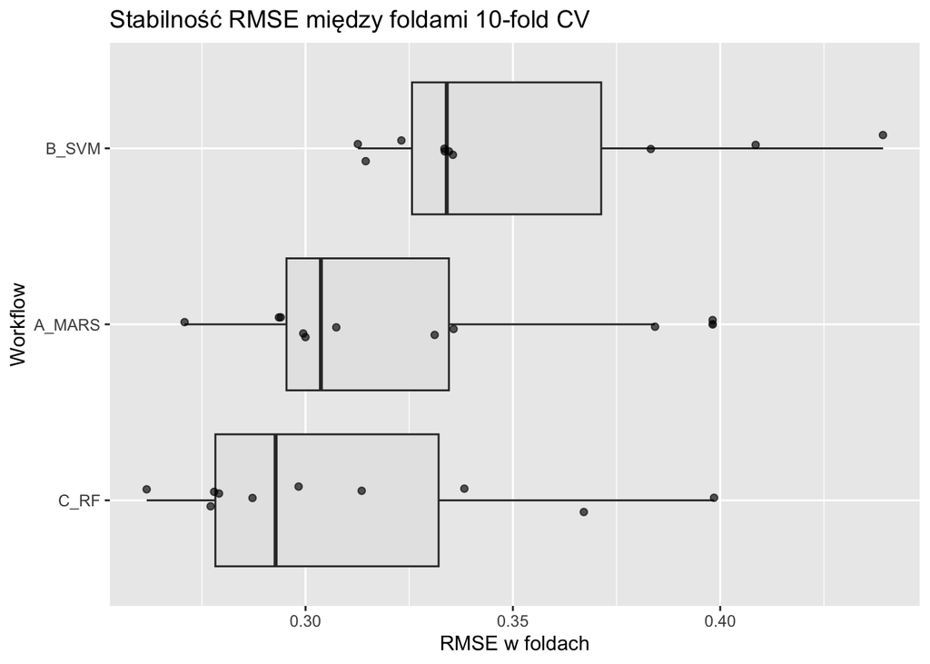

```r
sac_fold_rmse <- sac_res %>%
  collect_metrics(summarize = FALSE) %>%
  filter(.metric == "rmse")

sac_fold_rmse %>%
  ggplot(aes(x = reorder(wflow_id, .estimate, median),
             y = .estimate)) +
  geom_boxplot(fill = "grey90") +
  geom_point(alpha = 0.65, position = position_jitter(width = 0.08)) +
  coord_flip() +
  labs(
    x = "Workflow",
    y = "RMSE w foldach",
    title = "Stabilność RMSE między foldami 10-fold CV"
  )
```

### Formalne testy statystyczne

Porównujemy najlepszy workflow z każdym z pozostałych. Sparowany t-test porównuje średnie różnice RMSE na tych samych foldach i jest testem głównym. Test Wilcoxona traktujemy jako analizę odpornościową, mniej wrażliwą na odstępstwa od normalności różnic.

```r
best_wflow <- sac_ranking$wflow_id[1]
competitors <- sac_ranking$wflow_id[-1]

cat("Najlepszy workflow:", best_wflow, "\n")
```

```
Najlepszy workflow: C_RF
```

```r
cat("Pozostałe:", paste(competitors, collapse = ", "), "\n\n")
```

```
Pozostałe: A_MARS, B_SVM
```

```r
sac_tests <- purrr::map_dfr(competitors, function(comp_id) {
  wide <- sac_fold_rmse %>%
    filter(wflow_id %in% c(best_wflow, comp_id)) %>%
    select(id, wflow_id, .estimate) %>%
    pivot_wider(names_from = wflow_id, values_from = .estimate)

  t_res <- t.test(
    wide[[comp_id]],
    wide[[best_wflow]],
    paired = TRUE,
    alternative = "greater"
  )

  tibble(
    najlepszy     = best_wflow,
    konkurent     = comp_id,
    roznica_rmse  = mean(wide[[comp_id]] - wide[[best_wflow]]),
    p_value       = t_res$p.value
  )
})

sac_tests %>%
  knitr::kable(digits = 4,
    caption = "Porównanie sparowanym testem t-Studenta (H1: konkurent > najlepszy)")
```

Porównanie sparowanym testem t-Studenta (H1: konkurent > najlepszy)

| najlepszy | konkurent | roznica_rmse | p_value |
| --- | --- | --- | --- |
| C_RF | A_MARS | 0.0116 | 0.0032 |
| C_RF | B_SVM | 0.0419 | 0.0006 |

```r
sac_tests_w <- purrr::map_dfr(competitors, function(comp_id) {
  wide <- sac_fold_rmse %>%
    filter(wflow_id %in% c(best_wflow, comp_id)) %>%
    select(id, wflow_id, .estimate) %>%
    pivot_wider(names_from = wflow_id, values_from = .estimate)

  w_res <- wilcox.test(
    wide[[comp_id]],
    wide[[best_wflow]],
    paired = TRUE,
    alternative = "greater",
    exact = FALSE
  )

  tibble(
    najlepszy  = best_wflow,
    konkurent  = comp_id,
    p_value_wilcoxon = w_res$p.value
  )
})

sac_tests_w %>%
  knitr::kable(digits = 4,
    caption = "Potwierdzenie — sparowany test Wilcoxona")
```

Potwierdzenie — sparowany test Wilcoxona

| najlepszy | konkurent | p_value_wilcoxon |
| --- | --- | --- |
| C_RF | A_MARS | 0.0162 |
| C_RF | B_SVM | 0.0040 |

**Wniosek:** H0 zakłada równość średnich RMSE. H1 (jednostronna) mówi, że konkurent ma istotnie większy błąd. Jeżeli p-value < 0.05 — przewaga najlepszego modelu jest statystycznie istotna. W przeciwnym razie wybieramy model z najniższym średnim RMSE.

```r
cat("Do tuningu — wybrany workflow:", best_wflow, "\n")
```

```
Do tuningu — wybrany workflow: C_RF
```

## 6. Tuning hiperparametrów metodą symulowanego wyżarzania

### Wybór modelu i przestrzeń hiperparametrów

Najlepszym modelem w screeningu jest las losowy — dostrajamy jego hiperparametry: liczbę drzew (`trees`), liczbę losowanych predyktorów (`mtry`) oraz minimalną liczbę obserwacji w węźle (`min_n`).

```r
rf_tune_model <- rand_forest(
  trees = tune(), mtry = tune(), min_n = tune()
) %>%
  set_engine("ranger") %>%
  set_mode("regression")

rf_tune_wf <- workflow() %>%
  add_recipe(recipe_C) %>%
  add_model(rf_tune_model)
```

### Tuning metodą symulowanego wyżarzania (≥ 25 iteracji)

```r
set.seed(2026)
sa_ctrl <- control_sim_anneal(verbose = FALSE)

sa_results <- rf_tune_wf %>%
  tune_sim_anneal(
    resamples = sac_folds,
    iter = 25,
    metrics = metric_set(rmse),
    control = sa_ctrl
  )
```

### Najlepsze konfiguracje

```r
sa_best <- sa_results %>%
  show_best(n = 5, metric = "rmse")

sa_best %>%
  knitr::kable(digits = 4,
    caption = "Najlepsze konfiguracje po tuningu SA")
```

Najlepsze konfiguracje po tuningu SA

| mtry | trees | min_n | .metric | .estimator | mean | n | std_err | .config | .iter |
| --- | --- | --- | --- | --- | --- | --- | --- | --- | --- |
| 9 | 497 | 38 | rmse | standard | 0.3098 | 10 | 0.0140 | Iter14 | 14 |
| 8 | 930 | 39 | rmse | standard | 0.3100 | 10 | 0.0140 | Iter11 | 11 |
| 9 | 233 | 39 | rmse | standard | 0.3100 | 10 | 0.0142 | Iter17 | 17 |
| 10 | 694 | 38 | rmse | standard | 0.3101 | 10 | 0.0139 | Iter24 | 24 |
| 7 | 365 | 35 | rmse | standard | 0.3102 | 10 | 0.0139 | Iter15 | 15 |

### Przebieg tuningu

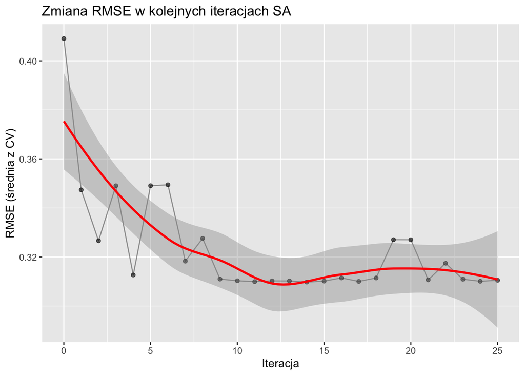

```r
sa_results %>%
  collect_metrics() %>%
  filter(.metric == "rmse") %>%
  ggplot(aes(x = .iter, y = mean)) +
  geom_point(alpha = 0.6) +
  geom_line(alpha = 0.4) +
  geom_smooth(method = "loess", se = TRUE, color = "red", span = 0.8) +
  labs(
    title = "Zmiana RMSE w kolejnych iteracjach SA",
    x = "Iteracja", y = "RMSE (średnia z CV)"
  )
```

### Porównanie statystyczne: tuning vs screening

```r
best_params <- sa_results %>%
  select_best(metric = "rmse")

final_tune_wf <- rf_tune_wf %>%
  finalize_workflow(best_params)

set.seed(2026)
tune_res <- final_tune_wf %>%
  fit_resamples(
    resamples = sac_folds,
    metrics = metric_set(rmse, mae, rsq),
    control = control_resamples(save_pred = TRUE)
  )

rmse_screening <- sac_fold_rmse %>%
  filter(wflow_id == best_wflow) %>%
  arrange(id) %>%
  pull(.estimate)

rmse_tuning <- tune_res %>%
  collect_metrics(summarize = FALSE) %>%
  filter(.metric == "rmse") %>%
  arrange(id) %>%
  pull(.estimate)

cat("H0: średni RMSE po tuningu = średni RMSE ze screeningu\n")
```

```
H0: średni RMSE po tuningu = średni RMSE ze screeningu
```

```r
cat("H1: średni RMSE po tuningu < średni RMSE ze screeningu\n\n")
```

```
H1: średni RMSE po tuningu < średni RMSE ze screeningu
```

```r
t_test <- t.test(rmse_tuning, rmse_screening,
                 paired = TRUE, alternative = "less")

cat("Średnia RMSE po tuningu:", round(mean(rmse_tuning), 4), "\n")
```

```
Średnia RMSE po tuningu: 0.3102
```

```r
cat("Średnia RMSE ze screeningu:",
    round(mean(rmse_screening), 4), "\n")
```

```
Średnia RMSE ze screeningu: 0.3099
```

```r
rmse_improvement <- mean(rmse_screening) - mean(rmse_tuning)

if (rmse_improvement > 0) {
  cat("Poprawa:", round(rmse_improvement, 4), "\n")
} else {
  cat("Tuning nie przyniósł poprawy; różnica:",
      round(rmse_improvement, 4), "\n")
}
```

```
Tuning nie przyniósł poprawy; różnica: -3e-04
```

```r
cat("p-value (test sparowany, jednostronny):",
    round(t_test$p.value, 5), "\n")
```

```
p-value (test sparowany, jednostronny): 0.56966
```

**Wniosek:** Jeżeli średni RMSE po tuningu jest niższy i p-value < 0.05, tuning przyniósł istotną statystycznie poprawę. W przeciwnym razie tuning nie poprawił wyniku screeningu i należy uczciwie raportować brak poprawy.

## 7. Ocena dopasowania na zbiorze testowym

```r
final_fit <- final_tune_wf %>%
  last_fit(
    sac_split,
    metrics = metric_set(rmse, mae, rsq)
  )

final_metrics <- collect_metrics(final_fit)
final_metrics %>%
  knitr::kable(digits = 4, caption = "Metryki na zbiorze testowym")
```

Metryki na zbiorze testowym

| .metric | .estimator | .estimate | .config |
| --- | --- | --- | --- |
| rmse | standard | 0.3067 | pre0_mod0_post0 |
| mae | standard | 0.2396 | pre0_mod0_post0 |
| rsq | standard | 0.6621 | pre0_mod0_post0 |

```r
rmse_test <- final_metrics %>%
  filter(.metric == "rmse") %>%
  pull(.estimate)

cat("RMSE testowy:", round(rmse_test, 4), "\n")
```

```
RMSE testowy: 0.3067
```

```r
cat("RMSE z CV (średnia po tuningu):",
    round(mean(rmse_tuning), 4), "\n")
```

```
RMSE z CV (średnia po tuningu): 0.3102
```

```r
cat("Różnica:", round(rmse_test - mean(rmse_tuning), 4), "\n")
```

```
Różnica: -0.0034
```

```r
rsq_test <- final_metrics %>%
  filter(.metric == "rsq") %>%
  pull(.estimate)
cat("R² testowy:", round(rsq_test, 4), "\n")
```

```
R² testowy: 0.6621
```

```r
if (rmse_test <= mean(rmse_tuning)) {
  cat("Komentarz: RMSE testowy nie jest większy od średniego RMSE z CV,",
      "co nie wskazuje na przetrenowanie.\n")
} else {
  cat("Komentarz: RMSE testowy jest większy od średniego RMSE z CV o",
      round(rmse_test - mean(rmse_tuning), 4),
      "co może wskazywać na słabszą generalizację na zbiorze testowym.\n")
}
```

```
Komentarz: RMSE testowy nie jest większy od średniego RMSE z CV, co nie wskazuje na przetrenowanie.
```

**Komentarz:** Wyniki są na skali `log(price)`. Interpretacja zależy od rzeczywistej różnicy między RMSE testowym i CV: niewielka różnica nie wskazuje na przetrenowanie, natomiast wyraźnie większy RMSE testowy oznacza słabszą generalizację. R² wskazuje, jaka część zmienności log(ceny) jest wyjaśniona przez model.

## 8. Graficzne porównanie wartości rzeczywistych i przewidywanych

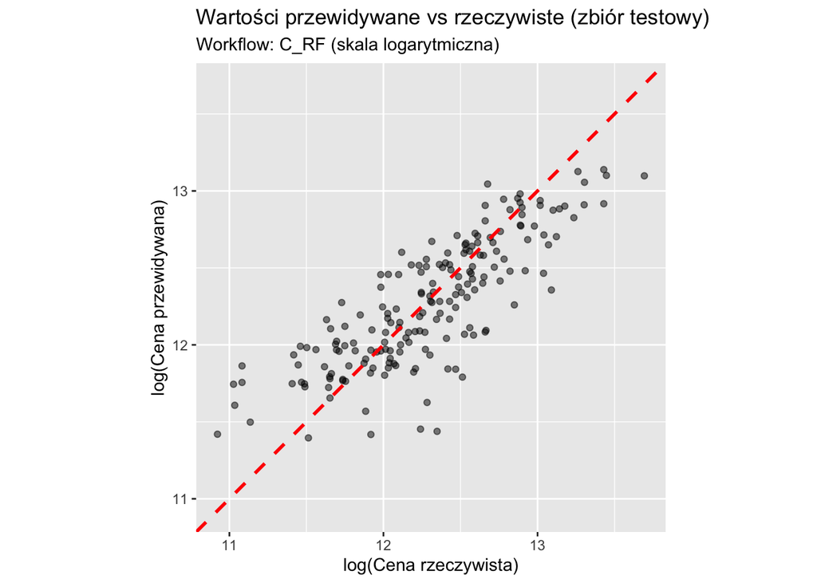

```r
final_fit %>%
  collect_predictions() %>%
  ggplot(aes(x = price, y = .pred)) +
  geom_point(alpha = 0.5) +
  geom_abline(slope = 1, intercept = 0, color = "red",
              linetype = "dashed", linewidth = 1) +
  coord_obs_pred() +
  labs(
    title = "Wartości przewidywane vs rzeczywiste (zbiór testowy)",
    subtitle = paste("Workflow:", best_wflow, "(skala logarytmiczna)"),
    x = "log(Cena rzeczywista)", y = "log(Cena przewidywana)"
  )
```